# Time Series Forecasting

Martial KOUASSI

2024-09-30

```r
options(repos = c(CRAN = "https://cran.rstudio.com/"))
```

#Introduction

Welcome to my report on time series forecasting to forecast electricity consumption (kW) of one building for 2/21/2010. I will use the historic electricity consumption data from 1/1/2010 1:15 to 2/20/2010 23:45. Two forecasts should be returned : ##1. The first one without using outdoor temperature, ##2. The second one using outdoor temperature.

I will follow the next steps: - Use Exponential Smoothing models to forcast electricity consumption - Use SARIMA models to forcast electricity consumption .The SARIMA model requires a variation of the data and its own EDA to estimate the model parameters - Use neural network models and other machine learning models to forcast electricity consumption - Use Use LSTM, deep LSTM and Dynamic regression model to forcast electricity consumption - Compare the results from the different models, draw key insights and outline next steps

#INSTALL PACKAGES

```r
install.packages("openxlsx")
library(openxlsx)
install.packages("readxl")
library(readxl)
```

#LOAD AND PLOT THE DATA

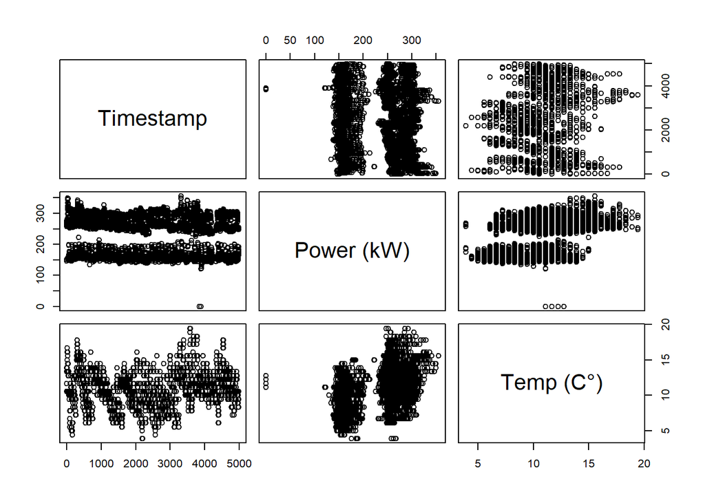

```r
data = read_excel('2023-11-Elec-train.xlsx')
plot(data)
```

#**Part 1: Forecast electricity consumption (kW) for 2/21/2010 without using outdoor temperature**

let’s plot and create the time series object

```r
library(forecast)
```

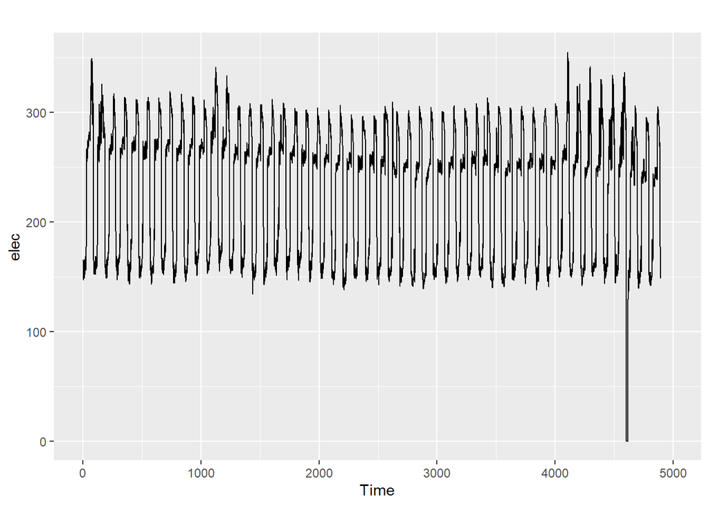

```r
library(ggplot2)
elec = ts(data$`Power (kW)`)
autoplot(elec)
```

##creation of ts object AS we have observations every 15 mins, we will make it by day. the frequency is 60*24/15=96

```r
elec_consum=ts(data[1:4891,2], start=c(1,6), end = c(51,96),frequency = 96)
tail(elec_consum)
```

```
## Time Series:
## Start = c(51, 91)
## End = c(51, 96)
## Frequency = 96
##      Power (kW)
## [1,]      272.5
## [2,]      271.2
## [3,]      269.8
## [4,]      189.6
## [5,]      177.9
## [6,]      148.4
```

##ploting the data

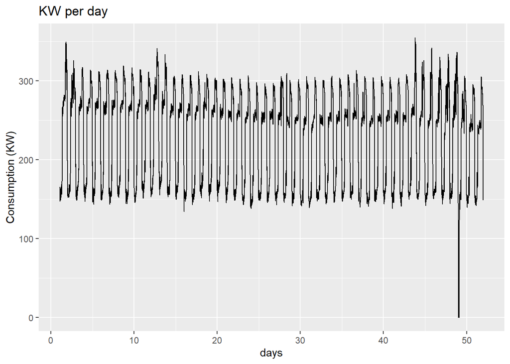

```r
autoplot(elec_consum)+
  ggtitle('KW per day')+
  xlab('days')+
  ylab('Consumption (KW)')
```

As we can see the plot above, it seems there are some outliers. We will try to handle it

```r
# Detect outliers in the time series
outliers = which(elec_consum==0)

# Print the detected outliers
print (outliers)
```

```
##  [1] 4604 4605 4606 4607 4608 4609 4610 4611 4612 4613 4614
```

```r
# Replace zero values with NA
elec_consum_NA=elec_consum
elec_consum_NA[outliers] <- NA

library(imputeTS)
```

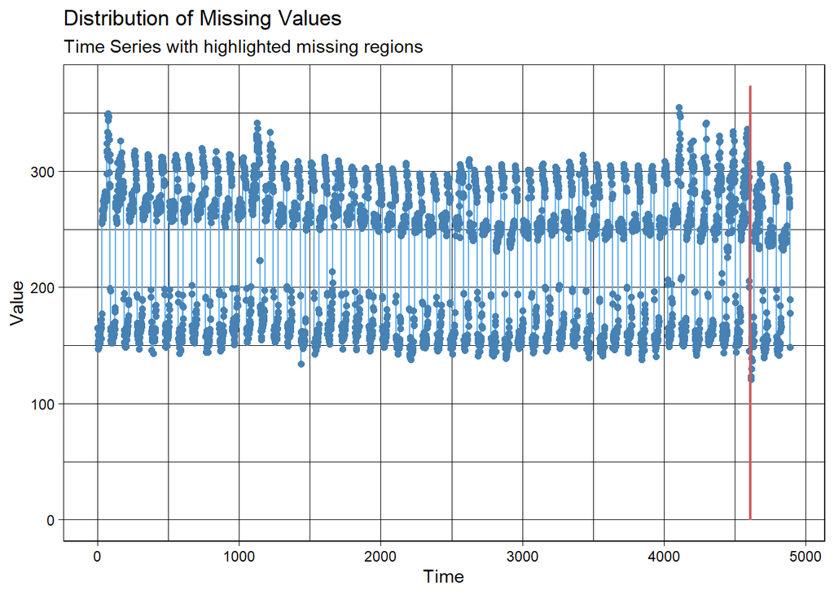

```r
# Plot the time series with detected outliers
ggplot_na_distribution(elec_consum_NA)
```

# Impute missing values using interpolation

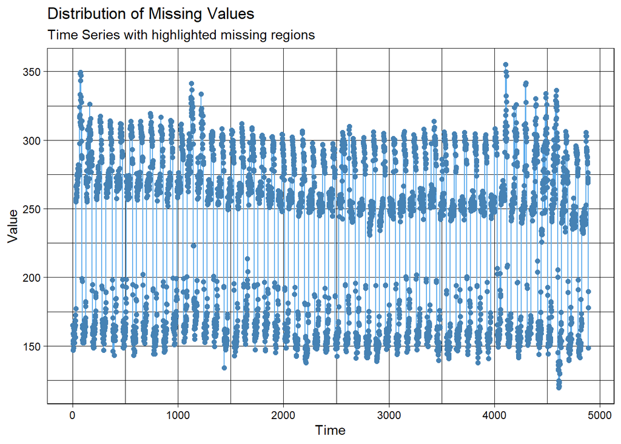

```r
elec_consum_i<- na.interp(elec_consum_NA)

#plot after interpolation
ggplot_na_distribution(elec_consum_i)
```

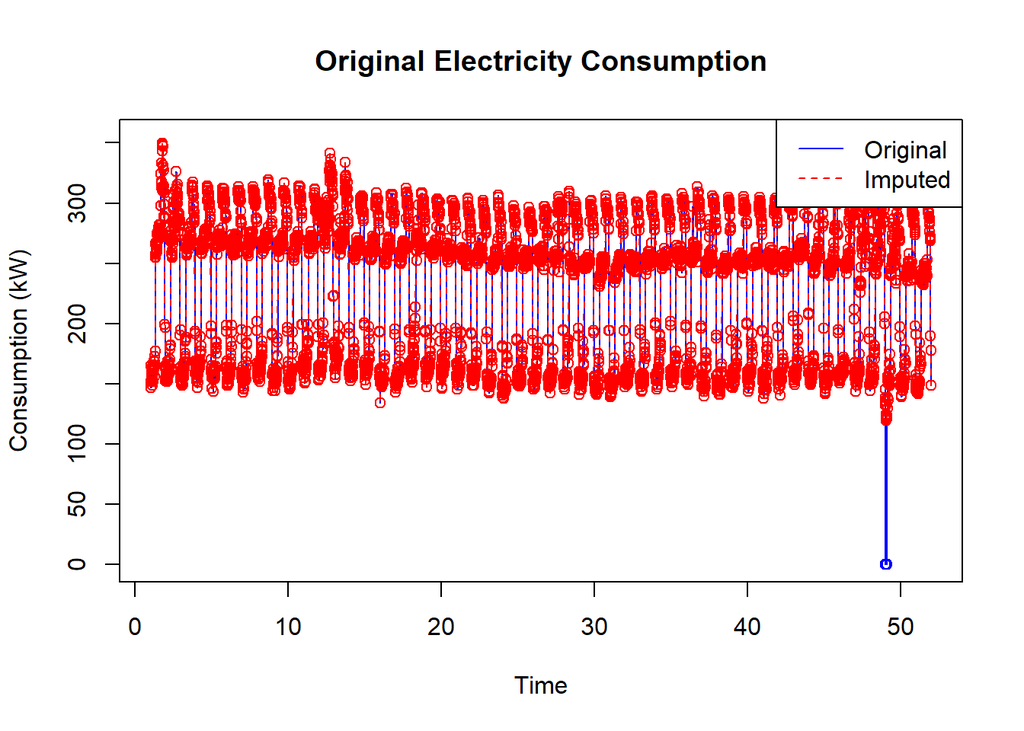

```r
# Plot the original and imputed time series
plot.ts(elec_consum, main="Original Electricity Consumption", ylab="Consumption (kW)", col="blue", type="o")
lines(elec_consum_i, col="red", type="o", lty=2)
legend("topright", legend=c("Original", "Imputed"), col=c("blue", "red"), lty=1:2)
```

```r
# Print the imputed time series
print(elec_consum_i[outliers])
```

```
##  [1] 138.4016 135.9332 132.9196 132.2571 135.4012 132.3401 124.4837 121.8882
##  [9] 119.3849 123.8997 123.1607
```

Now we split our time series dataset in two sets: train 80% and test 20% Since I have 4891 observations, I will get: - for the train set : 4891 * 0.8 = 3907 observations ( from 1 to 41) - for the test set : 4891 * 0.2 = 984 observations (from 42 to 51)

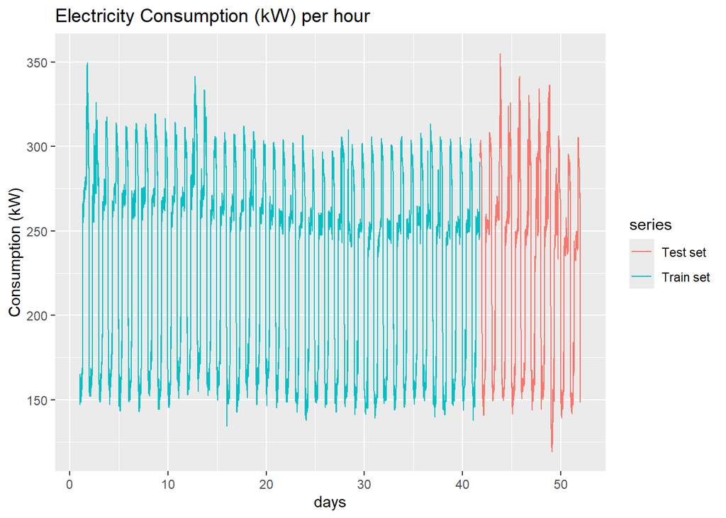

```r
elec_consum_train= window(elec_consum_i, start=c(1,6), end=c(41,72))
elec_consum_test= window(elec_consum_i, start=c(41,73), end=c(51,96))
autoplot(elec_consum_train,series="Train set") +
  autolayer(elec_consum_test,series='Test set')+
  ggtitle ('Electricity Consumption (kW) per hour') +
  xlab('days') +
  ylab('Consumption (kW)')
```

# Time-series models

```r
rmse = function(y_pred, y_true) {
# Calculate ROOT Mean Squared Error (RMSE)
  #
  # Args:
  #   y_true: vector of true values
  #   y_pred: vector of predicted values
  #
  # Returns:
  #   rmse: RMSE value for the given predicted values



  # Calculate MSE
  rmse = sqrt(mean((y_pred - y_true )^2))
  return(rmse)
}
```

# **Forecasting with exponential smoothing**

We see a seasonal pattern, probably additive. Because of the frequency limit of 24, we cannot fit a Holt-Winters additive model

# ** Forcasting with SARIMA models**

# *** Automatically***

We choose automaticaly an SARIMA model

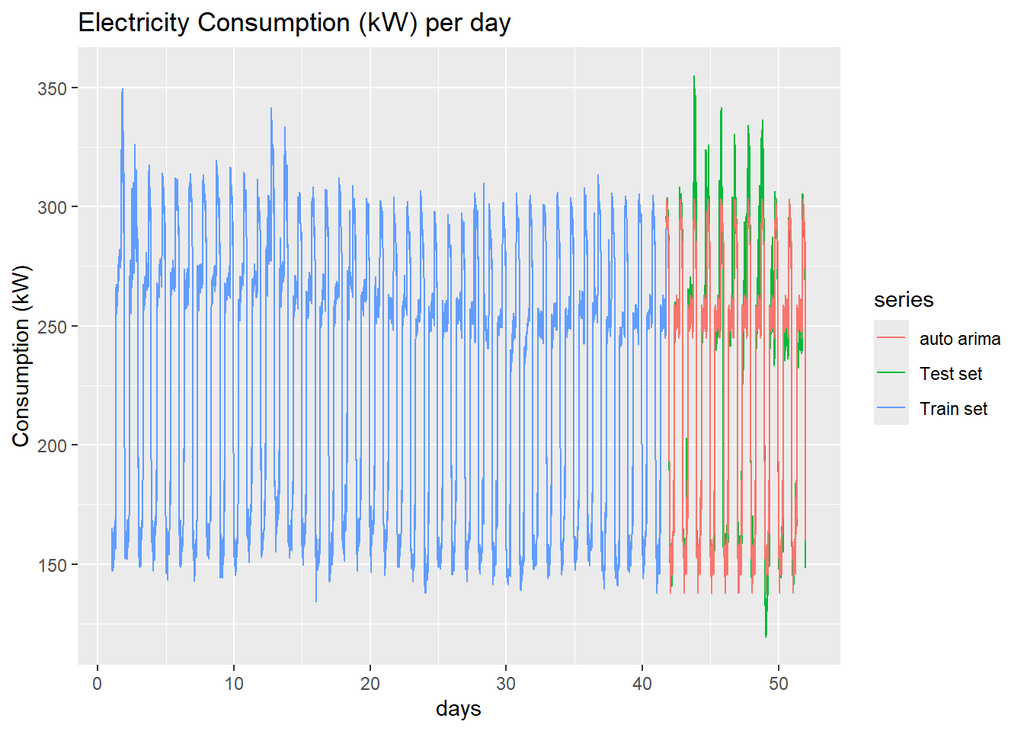

```r
elec_consum_aut=auto.arima(elec_consum_train,lambda = "auto")
prev_aut=forecast(elec_consum_aut, h=984)


#plot in a graph
autoplot(elec_consum_train,series="Train set") +
  autolayer(elec_consum_test,series='Test set')+
  autolayer(prev_aut$mean,series='auto arima')+
  ggtitle ('Electricity Consumption (kW) per day') +
  xlab('days') +
  ylab('Consumption (kW)')
```

```r
summary(elec_consum_aut)
```

```
## Series: elec_consum_train
## ARIMA(5,0,0)(0,1,0)[96]
## Box Cox transformation: lambda= -0.01102751
##
## Coefficients:
##          ar1     ar2      ar3      ar4     ar5
##       0.7752  0.1390  -0.0687  -0.2499  0.1786
## s.e.  0.0159  0.0199   0.0200   0.0199  0.0159
##
## sigma^2 = 0.001688:  log likelihood = 6760.18
## AIC=-13508.37   AICc=-13508.35   BIC=-13470.89
##
## Training set error measures:
##                       ME     RMSE     MAE        MPE     MAPE     MASE
## Training set -0.04130911 9.475386 5.79422 -0.1101576 2.652868 0.725453
##                    ACF1
## Training set 0.03228393
```

Let’s evaluate the SARIMA (5,0,0)(0,1,0)[96] model by computing the RMSE

```r
sarima_model = rmse(prev_aut$mean,elec_consum_test)
sarima_model
```

```
## [1] 15.7896
```

The prediction from this model doesn’t look bad, but let check if we can improve it.

# ** Forcasting with Neural Network models**

We can try a auto-regressive neural network

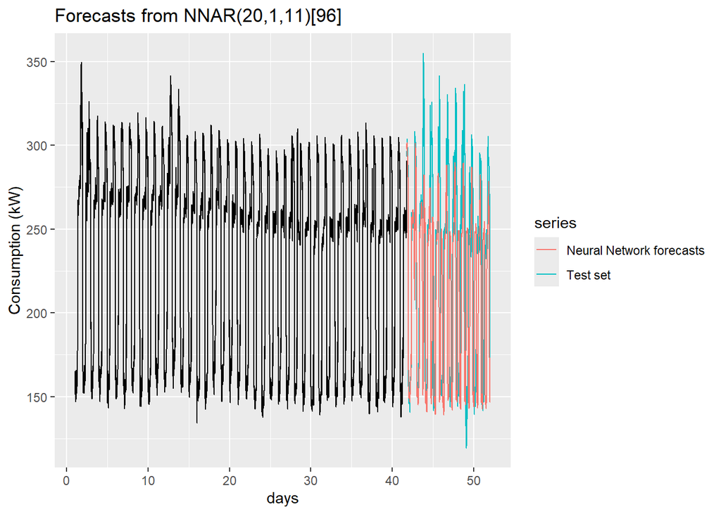

```r
elec_consum_NN =nnetar(elec_consum_train, lambda = 'auto')
prev_NN=forecast(elec_consum_NN, h=984)

#plot in a graph
autoplot(prev_NN) +
  autolayer(elec_consum_test,series='Test set')+
  autolayer(prev_NN$mean, series="Neural Network forecasts")+

  xlab('days') +
  ylab('Consumption (kW)')
```

```r
summary(elec_consum_NN)
```

```
##           Length Class        Mode
## x         3907   ts           numeric
## m            1   -none-       numeric
## p            1   -none-       numeric
## P            1   -none-       numeric
## scalex       2   -none-       list
## size         1   -none-       numeric
## lambda       1   -none-       numeric
## subset    3907   -none-       numeric
## model       20   nnetarmodels list
## nnetargs     0   -none-       list
## fitted    3907   ts           numeric
## residuals 3907   ts           numeric
## lags        21   -none-       numeric
## series       1   -none-       character
## method       1   -none-       character
## call         3   -none-       call
```

Let’s evaluate the Neural Network model by computing the RMSE

```r
neural_network = rmse(prev_NN$mean,elec_consum_test)
neural_network
```

```
## [1] 67.8081
```

The score is not better that the previous model (SARIMA), we will try other machine learning models

#** Forcasting with Random forest**

We based our forecast on the 96 previous observations, but that can be optimized (by CV)

```r
data=as.vector(elec_consum_train)[1:97]
for (i in 1:(length(as.vector(elec_consum_train))-97)){
data=rbind(data,as.vector(elec_consum_train)[(i+1):(i+97)])
}
```

We fit the model

```r
library(randomForest)
elec_consum_RF=randomForest(x=data[,-97], y=data[,97])
```

And then sequentially forecast the next 984 values

```r
pred=rep(NULL,984)
newdata=tail(elec_consum_train,96)
for (t in 1:984){
pred[t]=predict(elec_consum_RF,newdata=newdata)
newdata=c(newdata[-1],pred[t])
}
prev_RF=ts(pred,start=c(41,73), end=c(51,96),frequency = 96)
```

Let’s evaluate the Random Forest model by computing the RMSE

```r
Random_Forest = rmse(prev_RF,elec_consum_test)
Random_Forest
```

```
## [1] 15.95456
```

the score with random forest model is not bad, but not better than SARIMA.

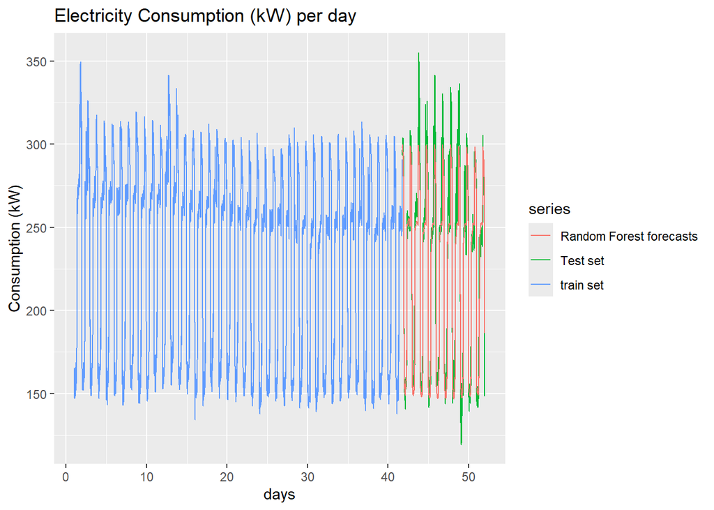

```r
#plot in a graph
autoplot(elec_consum_train, series = 'train set') +
  autolayer(elec_consum_test,series='Test set')+
  autolayer(prev_RF, series="Random Forest forecasts")+
  ggtitle ('Electricity Consumption (kW) per day') +
  xlab('days') +
  ylab('Consumption (kW)')
```

let’s try if we get better result with XG BOOST

#** Forcasting with XG Boost##

with default values, which should have to be optimized by Cross Validation.

```r
install.packages("xgboost")
library("xgboost")
model<- xgboost(data = data[,1:96], label = data[,97],
max_depth = 10, eta = .5, nrounds = 200,
nthread = 2, objective = "reg:squarederror")
```

And then sequentially forecast the next 984 values

```r
pred_XGB=rep(NULL,984)
newdata=tail(elec_consum_train,96)
for (t in 1:984){
pred_XGB[t]=predict(model,matrix(newdata,1,96))
newdata=c(newdata[-1],pred[t])
}
prev_XGB=ts(pred_XGB,start=c(41,73), end=c(51,96),frequency = 96)
```

Let’s evaluate the XG BOOST model by computing the RMSE

```r
XG_boost = rmse(prev_XGB,elec_consum_test)
XG_boost
```

```
## [1] 16.87228
```

#First conclusion

let’s resume all score we get and choose the best one.

```r
cat('Forecasting results : ' , '\n')
```

```
## Forecasting results :
```

```r
cat('RMSE with SARIMA model is:', sarima_model ,'\n')
```

```
## RMSE with SARIMA model is: 15.7896
```

```r
cat('RMSE with Neural Network model is:', neural_network ,'\n')
```

```
## RMSE with Neural Network model is: 67.8081
```

```r
cat('RMSE with Random Forest is:', Random_Forest ,'\n')
```

```
## RMSE with Random Forest is: 15.95456
```

```r
cat('RMSE with XGB BOOST model is:', XG_boost ,'\n')
```

```
## RMSE with XGB BOOST model is: 16.87228
```

SARIMA model (5,0,0)(0,1,0)[96] is definitely our best model so far.

let’s clearly see the prediction

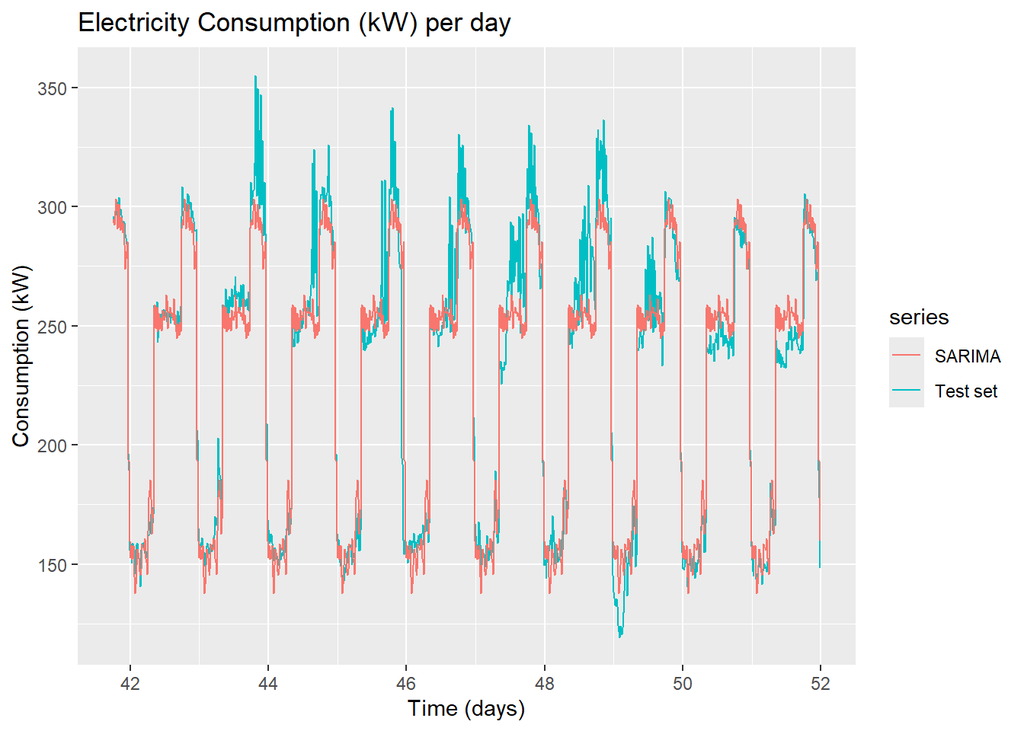

```r
autoplot(elec_consum_test,series='Test set') +
  autolayer(prev_aut$mean,series='SARIMA')+
  ggtitle ('Electricity Consumption (kW) per day') +
  xlab('Time (days)') +
  ylab('Consumption (kW)')
```

We will now forecast the electricity consumption (kW) for 2/21/2010 based on the whole previous consumption information (ARIMA (5,0,0)(0,1,0)[96]).  
The prediction interval = 24 hr for the entire day of 2/21/2010.So h =(24*60)/15 = 96 observations

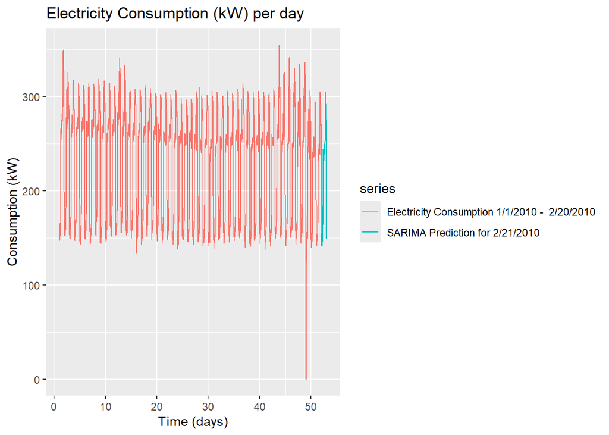

```r
elec_consum_21 = Arima(elec_consum_i, order=c(5,0,0), seasonal=c(0,1,0),lambda = "auto")
prev_consum_21 = forecast(elec_consum_21, h = 96)
autoplot(elec_consum,series="Electricity Consumption 1/1/2010 -  2/20/2010") +
  autolayer(prev_consum_21$mean,series='SARIMA Prediction for 2/21/2010')+
  ggtitle ('Electricity Consumption (kW) per day') +
  xlab('Time (days)') +
  ylab('Consumption (kW)')
```

#Prediction results

```r
print(prev_consum_21$mean)
```

```
## Time Series:
## Start = c(52, 1)
## End = c(52, 96)
## Frequency = 96
##  [1] 145.2782 141.4785 141.8207 149.9394 151.9718 152.5775 142.5537 144.9439
##  [9] 141.8290 147.9143 153.8950 149.2115 148.3811 146.4706 141.3151 146.9511
## [17] 150.1871 150.0068 148.1296 148.7453 147.7558 146.7668 151.0732 150.0788
## [25] 152.3837 161.6865 184.0887 173.5915 169.6933 164.1950 164.4960 167.9968
## [33] 166.2976 243.9976 241.0981 234.5986 238.9989 239.9991 234.1993 235.3995
## [41] 238.2996 232.4997 237.0997 235.3998 233.7998 232.6999 234.0999 232.2999
## [49] 242.8999 243.2000 240.1000 247.6000 246.4000 244.1000 250.0000 242.8000
## [57] 239.8000 244.3000 243.9000 245.2000 249.9000 244.4000 247.2000 242.4000
## [65] 241.5000 240.0000 240.4000 238.4000 241.8000 246.1000 239.7000 252.8000
## [73] 299.2000 302.9000 305.5000 292.6000 294.5000 303.1000 293.4000 291.3000
## [81] 292.6000 288.9000 291.9000 292.9000 287.9000 287.4000 282.6000 284.5000
## [89] 276.2000 268.9000 272.5000 271.2000 269.8000 189.6000 177.9000 148.4000
```

```r
forecasts <- data.frame(
  Timestamp = seq(from = as.POSIXct("2010-02-21 00:00"), by = "15 min", length.out = 96),
  Forecast = as.numeric(round(prev_consum_21$mean,1))
)
# Create a new workbook
wb <- createWorkbook()

# Add a worksheet
addWorksheet(wb, "Forecasts")

# Write the data to the worksheet
writeData(wb, "Forecasts", forecasts)


# Save the workbook
saveWorkbook(wb, "Martial_KOUASSI.xlsx", overwrite = TRUE)

# Output message
print("Forecasts saved to Martial_KOUASSI.xlsx")
```

```
## [1] "Forecasts saved to Martial_KOUASSI.xlsx"
```

#**Part 2: Forecast electricity consumption (kW) for 2/21/2010 by using outdoor temperature**

let’s create the time series object

```r
data = read_excel('2023-11-Elec-train.xlsx')
elec_consum_t=ts(data[1:4891,2:3], start=c(1,6), end = c(51,96),frequency = 96,)
tail(elec_consum_t)
```

```
## Time Series:
## Start = c(51, 91)
## End = c(51, 96)
## Frequency = 96
##          Power (kW) Temp (C°)
## 51.93750      272.5  11.66667
## 51.94792      271.2  11.66667
## 51.95833      269.8  11.66667
## 51.96875      189.6  11.66667
## 51.97917      177.9  11.66667
## 51.98958      148.4  11.66667
```

#ploting the ts

```r
library(fpp2)
```

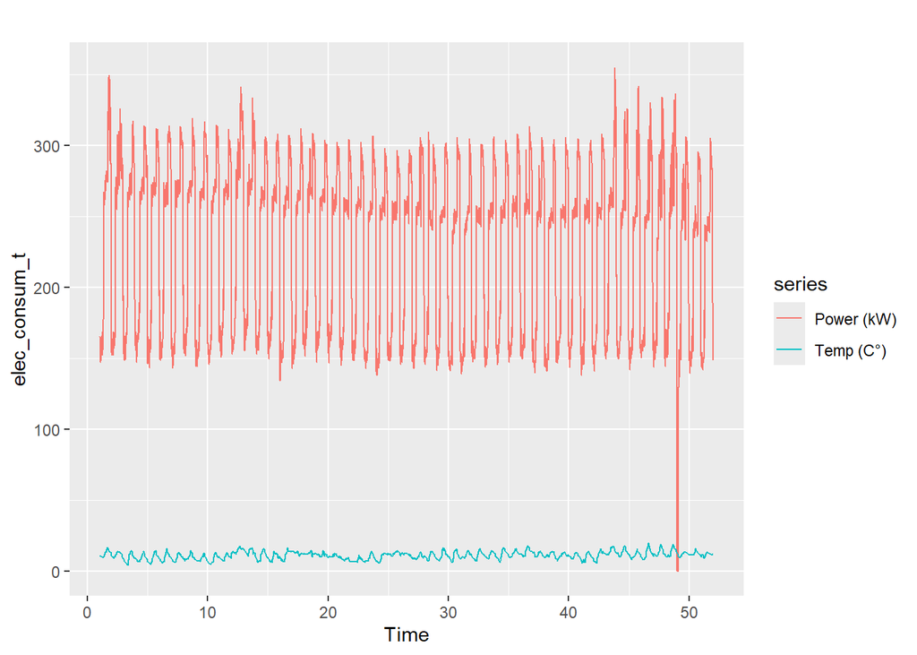

```r
autoplot(elec_consum_t)
```

#HANDLE OUTLIERS

```r
outlierst=which(elec_consum_t==0)
elec_consum_t[outlierst]= elec_consum_i[outliers]
elec_consum_t[4604:4614,]
```

```
##       Power (kW) Temp (C°)
##  [1,]   138.4016  12.77778
##  [2,]   135.9332  12.22222
##  [3,]   132.9196  12.22222
##  [4,]   132.2571  12.22222
##  [5,]   135.4012  12.22222
##  [6,]   132.3401  11.66667
##  [7,]   124.4837  11.66667
##  [8,]   121.8882  11.66667
##  [9,]   119.3849  11.66667
## [10,]   123.8997  11.11111
## [11,]   123.1607  11.11111
```

We split into train and test

```r
elec_consumt_train= window(elec_consum_t, start=c(1,6), end=c(41,72))
elec_consumt_test= window(elec_consum_t, start=c(41,73), end=c(51,96))
```

#**Forecasting with ARIMA model**

We will use a dynamic regression model for forecasting electricity consumption, using temperature as external covariates. The order of the ARIMA model for the residual part is automatically selected

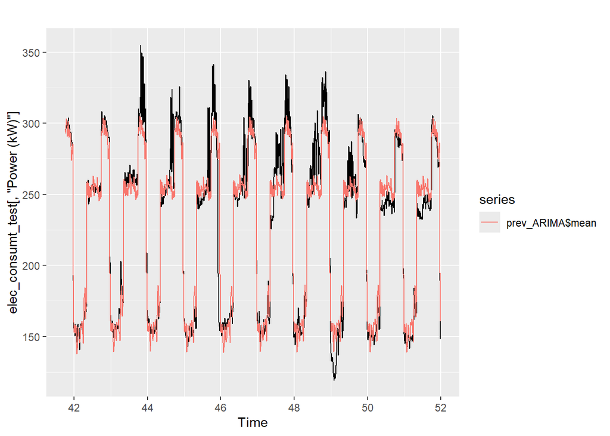

```r
ARIMA=auto.arima(elec_consumt_train[,"Power (kW)"],xreg=elec_consumt_train[,2])
prev_ARIMA=forecast(ARIMA,h=984,xreg=elec_consumt_test[,2])
autoplot(elec_consumt_test[,"Power (kW)"])+autolayer(prev_ARIMA$mean)
```

let’s evaluate this model

```r
arima_score = rmse(prev_ARIMA$mean,elec_consumt_test[,"Power (kW)"])
arima_score
```

```
## [1] 15.61163
```

we can see that using covariates allows us to improve the forecasting. But if we check the residual, there is still some autocorrelations:

```r
summary(ARIMA)
```

```
## Series: elec_consumt_train[, "Power (kW)"]
## Regression with ARIMA(1,0,0)(0,1,0)[96] errors
##
## Coefficients:
##          ar1    xreg
##       0.7734  0.3283
## s.e.  0.0103  0.2396
##
## sigma^2 = 98.76:  log likelihood = -14158.36
## AIC=28322.72   AICc=28322.73   BIC=28341.46
##
## Training set error measures:
##                       ME     RMSE     MAE        MPE     MAPE      MASE
## Training set -0.07249998 9.812342 5.73861 -0.1211996 2.648591 0.7184904
##                     ACF1
## Training set -0.01365387
```

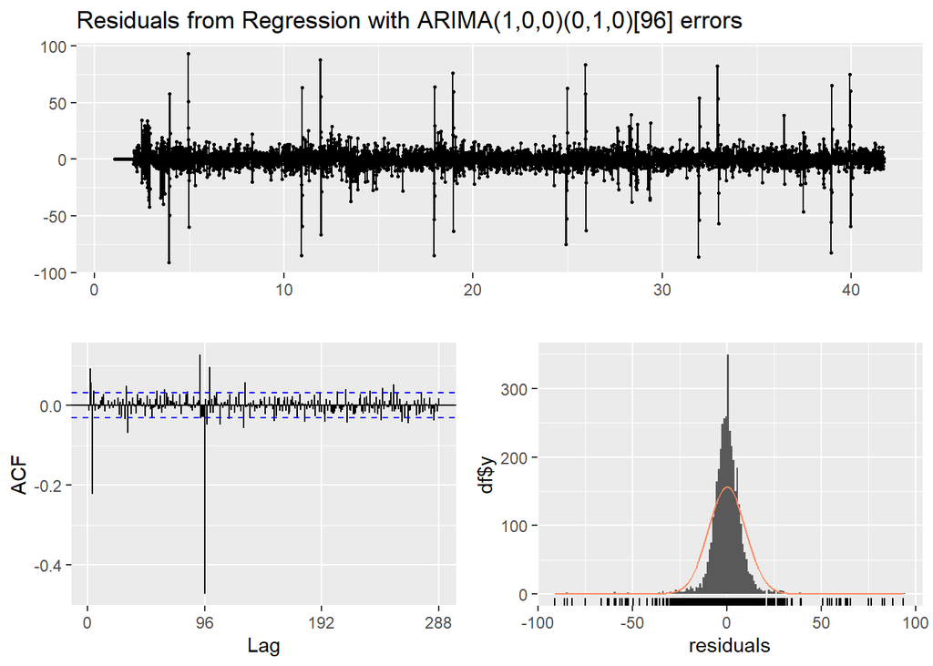

```
##
##  Ljung-Box test
##
## data:  Residuals from Regression with ARIMA(1,0,0)(0,1,0)[96] errors
## Q* = 1523.5, df = 191, p-value < 2.2e-16
##
## Model df: 1.   Total lags used: 192
```

```r
checkresiduals(ARIMA)
```

We can try to find a better model manually. Let’s have a look to the relationship between consumption and Temperature

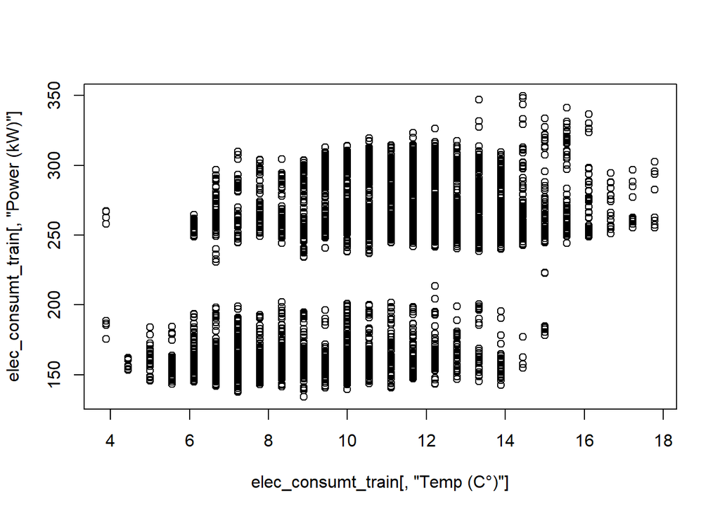

```r
plot(elec_consumt_train[,"Temp (C°)"],elec_consumt_train[,"Power (kW)"])
```

**incorporate time-dependent patterns and seasonality in our analysis**

```r
effect_temperature_on_consum=tslm(elec_consumt_train[,'Power (kW)']~elec_consumt_train[,'Temp (C°)']+trend+season,data=elec_consumt_train)
summary(effect_temperature_on_consum)
```

```
##
## Call:
## tslm(formula = elec_consumt_train[, "Power (kW)"] ~ elec_consumt_train[,
##     "Temp (C°)"] + trend + season, data = elec_consumt_train)
##
## Residuals:
##      Min       1Q   Median       3Q      Max
## -112.370   -4.606    0.176    4.654   58.696
##
## Coefficients:
##                                     Estimate Std. Error t value Pr(>|t|)
## (Intercept)                        1.567e+02  2.070e+00  75.699  < 2e-16 ***
## elec_consumt_train[, "Temp (C°)"]  1.096e+00  9.629e-02  11.383  < 2e-16 ***
## trend                             -4.732e-03  1.679e-04 -28.186  < 2e-16 ***
## season2                           -5.182e-01  2.600e+00  -0.199  0.84202
## season3                           -6.678e+00  2.600e+00  -2.569  0.01024 *
## season4                           -3.412e-01  2.600e+00  -0.131  0.89559
## season5                            2.859e+00  2.600e+00   1.100  0.27159
## season6                            3.154e+00  2.584e+00   1.220  0.22239
## season7                           -6.529e+00  2.584e+00  -2.527  0.01155 *
## season8                           -6.766e+00  2.584e+00  -2.618  0.00887 **
## season9                           -3.322e+00  2.584e+00  -1.286  0.19863
## season10                          -4.037e+00  2.585e+00  -1.562  0.11835
## season11                          -1.196e+00  2.585e+00  -0.463  0.64359
## season12                          -2.006e+00  2.585e+00  -0.776  0.43774
## season13                          -4.108e-01  2.585e+00  -0.159  0.87370
## season14                          -5.115e+00  2.585e+00  -1.978  0.04796 *
## season15                          -6.556e+00  2.585e+00  -2.536  0.01125 *
## season16                          -9.637e-01  2.585e+00  -0.373  0.70934
## season17                           6.874e-01  2.585e+00   0.266  0.79034
## season18                          -2.546e-01  2.586e+00  -0.098  0.92160
## season19                          -1.167e+00  2.586e+00  -0.451  0.65189
## season20                           5.159e-01  2.586e+00   0.199  0.84192
## season21                           1.499e-01  2.586e+00   0.058  0.95380
## season22                           1.079e+00  2.587e+00   0.417  0.67667
## season23                           1.898e+00  2.587e+00   0.734  0.46315
## season24                           4.074e+00  2.587e+00   1.575  0.11543
## season25                           3.508e+00  2.587e+00   1.356  0.17523
## season26                           6.991e+00  2.587e+00   2.702  0.00692 **
## season27                           1.400e+01  2.587e+00   5.412 6.61e-08 ***
```

[output cut: 60 more lines]

```
## season88                           1.314e+02  2.600e+00  50.536  < 2e-16 ***
## season89                           1.292e+02  2.600e+00  49.684  < 2e-16 ***
## season90                           1.122e+02  2.599e+00  43.145  < 2e-16 ***
## season91                           1.108e+02  2.599e+00  42.631  < 2e-16 ***
## season92                           1.047e+02  2.599e+00  40.291  < 2e-16 ***
## season93                           1.058e+02  2.599e+00  40.720  < 2e-16 ***
## season94                           2.994e+01  2.599e+00  11.519  < 2e-16 ***
## season95                           3.209e+01  2.599e+00  12.344  < 2e-16 ***
## season96                           2.910e+00  2.599e+00   1.120  0.26294
## ---
## Signif. codes:  0 '***' 0.001 '**' 0.01 '*' 0.05 '.' 0.1 ' ' 1
##
## Residual standard error: 11.62 on 3809 degrees of freedom
## Multiple R-squared:  0.9598, Adjusted R-squared:  0.9588
## F-statistic: 938.5 on 97 and 3809 DF,  p-value: < 2.2e-16
```

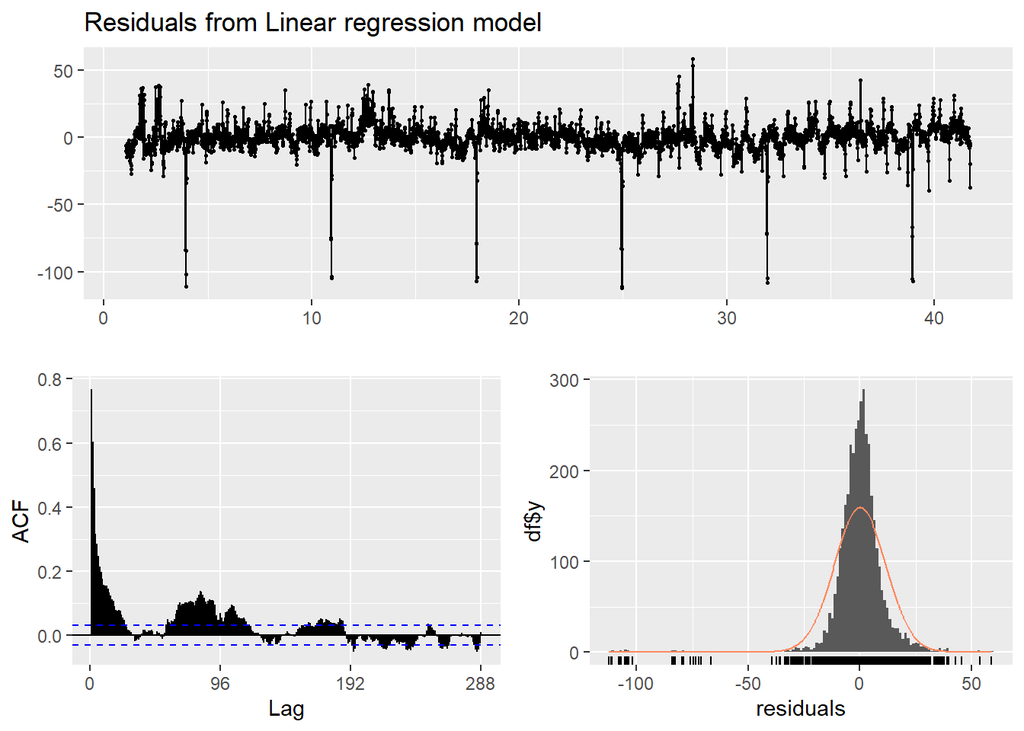

```
##
##  Breusch-Godfrey test for serial correlation of order up to 192
##
## data:  Residuals from Linear regression model
## LM test = 2478.6, df = 192, p-value < 2.2e-16
```

```r
checkresiduals(effect_temperature_on_consum)
```

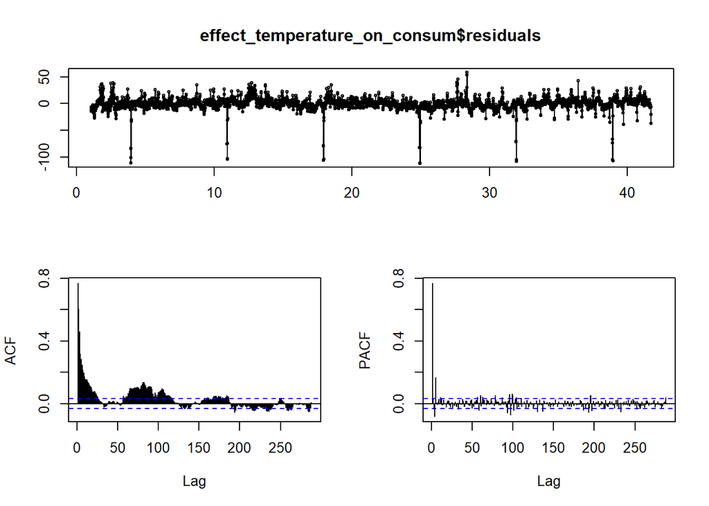

```r
tsdisplay(effect_temperature_on_consum$residuals)
```

The ACP and PACF look like those of an AR11 model: exponential decrease of the ACF and significant PCA at lag 5. We can test it:

```r
tmp=effect_temperature_on_consum$residuals
effect_temperature_on_consum2=auto.arima(tmp,lambda = 'auto')
```

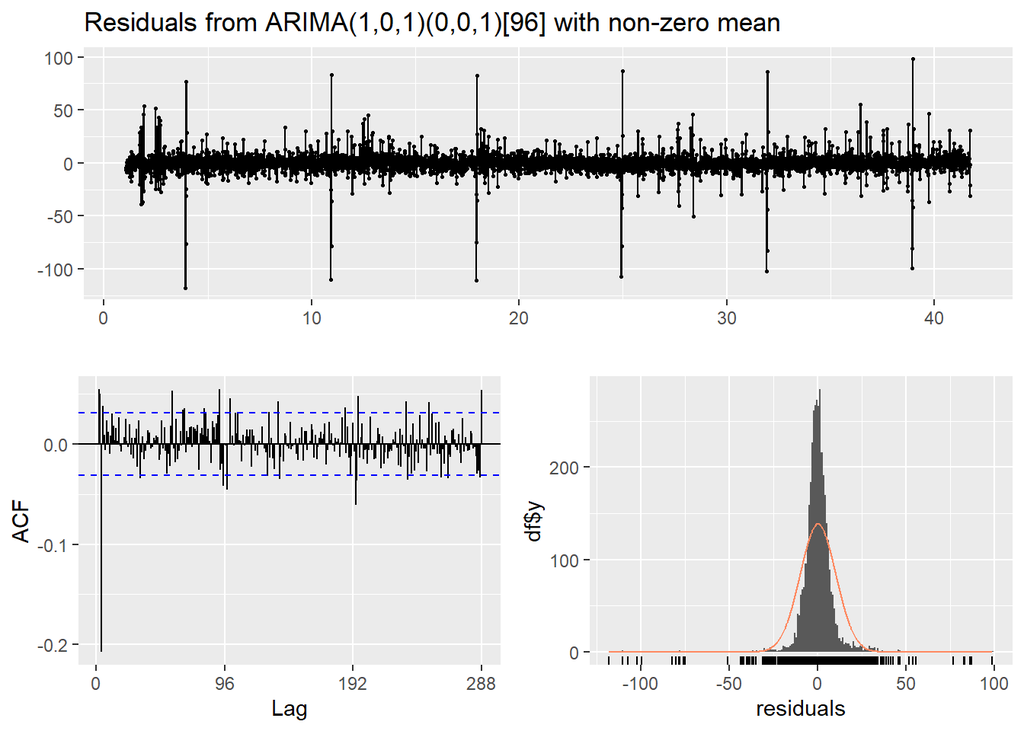

```
##
##  Ljung-Box test
##
## data:  Residuals from ARIMA(1,0,1)(0,0,1)[96] with non-zero mean
## Q* = 422.85, df = 189, p-value < 2.2e-16
##
## Model df: 3.   Total lags used: 192
```

```r
checkresiduals(effect_temperature_on_consum2)
```

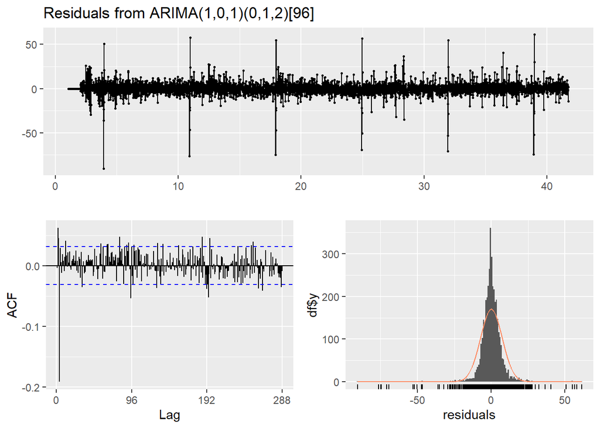

```
##
##  Ljung-Box test
##
## data:  Residuals from ARIMA(1,0,1)(0,1,2)[96]
## Q* = 434.06, df = 188, p-value < 2.2e-16
##
## Model df: 4.   Total lags used: 192
```

```r
effect_temperature_on_consum3=arima(tmp,order=c(1,0,1), seasonal = c(0,1,2))
checkresiduals(effect_temperature_on_consum3)
```

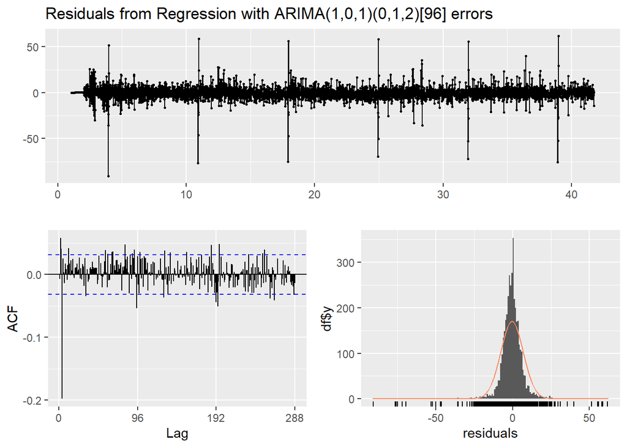

```
##
##  Ljung-Box test
##
## data:  Residuals from Regression with ARIMA(1,0,1)(0,1,2)[96] errors
## Q* = 445.1, df = 188, p-value < 2.2e-16
##
## Model df: 4.   Total lags used: 192
```

```r
fit=Arima(elec_consumt_train[,"Power (kW)"],xreg=elec_consumt_train[,2],order=c(1,0,1),seasonal = c(0,1,2))
checkresiduals(fit)
```

We can perform forecasting:

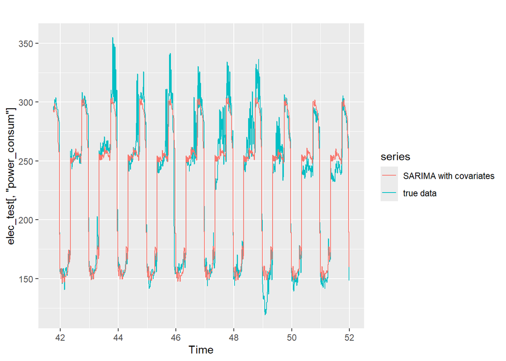

```r
elec_test=cbind(power_consum=elec_consumt_test[,1],Temp=elec_consumt_test[,2])
prev_t=forecast(fit,h=984,xreg=elec_consumt_test[,2])
autoplot(elec_test[,"power_consum"], series="true data")+autolayer(prev_t$mean,series="SARIMA with covariates")
```

let evaluate this model

```r
SARIMA_COVARIATES= rmse(prev_t$mean,elec_test[,"power_consum"])
SARIMA_COVARIATES
```

```
## [1] 14.89199
```

The result are better than those obtained with the auto.arima function.

Let’s try a a Neural Network model with covariates.